# Homework 08

Your Name

## Problem 1: regression warm up

This problem uses linear regression to estimate creatinine clearance based on patient age.

### What creatinine clearance rate should we expect for a 55-year-old? Explain briefly (one or two sentences + equations) how you determined this.

```
## Predicted creatinine clearance rate for a 55-year-old: 113.723 mL/minute
```

With our regression model fitted to the data, we predict the creatinine clearance rate for a 55-year-old using the equation:

$$\hat{y} = \beta_0 + \beta_1 \cdot \text{age}$$

Substituting in age = 55, we calculate:

$$\hat{y} = \text{(Intercept)} + \text{(Slope)} \cdot 55 = 113.72$$

Thus, the expected creatinine clearance rate for a 55-year-old is approximately 113.72 mL/min.

### How does creatinine clearance rate change with age? (This should be a single number whose units are ml/minute per year.) Explain briefly (one or two sentences) how you determined this.

```
## Slope: -0.6198159 mL/minute per year
```

We find the slope for age from the model, which is just the change in creatinine clearance rate.

### Whose creatinine clearance rate is healthier (higher) for their age: a 40-year-old with a rate of 135, or a 60-year-old with a rate of 112? Explain briefly (a few sentences + equations) how you determined this.

Residual formula:

$$\text{Residual} = \text{Observed value} - \text{Predicted value}$$

For the 40-year-old:

$$\text{Residual}_{40} = 135 - \hat{y}_{40} = 135 - (\beta_0 + \beta_1
\cdot 40)$$

For the 60-year-old:

$$\text{Residual}_{60} = 112 - \hat{y}_{60} = 112 - (\beta_0 + \beta_1
\cdot 60)$$

Using the regression model, we obtained:

```
## 40-year-old's residual: 11.97972 mL/minute
```

```
## 60-year-old's residual: 1.376035 mL/minute
```

The 40-year-old has the healthier creatinine clearance rate for their age because the residual for a 40-year-old is higher.

## Problem 2: Modeling disease growth

```
## Italy Growth Rate: 0.183
```

```
## Italy Growth Rate Confidence Interval: 0.157 - 0.209
```

```
## Italy Doubling Time: 3.8
```

```
## Italy Doubling Time Confidence Interval: 3.3 - 4.4
```

```
## Spain Growth Rate: 0.276
```

```
## Spain Growth Rate Confidence Interval: 0.235 - 0.317
```

```
## Spain Doubling Time: 2.5
```

```
## Spain Doubling Time Confidence Interval: 2.2 - 3
```

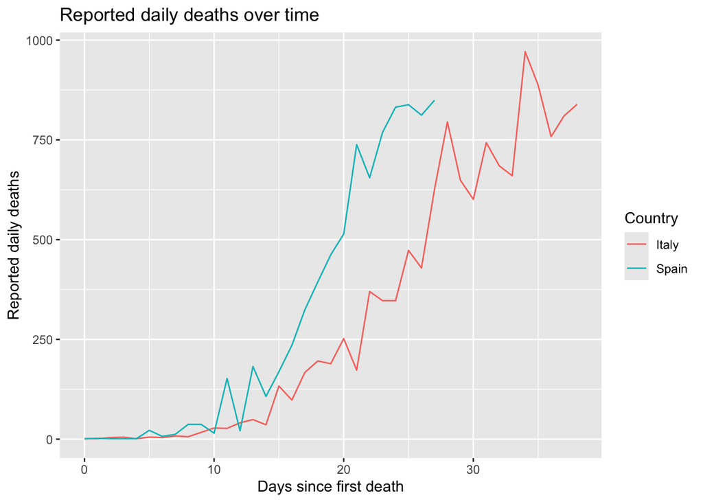

```r
ggplot(covid, aes(x = days_since_first_death, y = deaths, color = country)) +
  geom_line() +
  labs(title = "Reported daily deaths over time",
       x = "Days since first death",
       y = "Reported daily deaths",
       color = "Country")
```

## Problem 3: Price Elasticity of Milk

```
## Price elasticity of demand: -1.619
```

```
## Confidence Interval for price elasticity of demand: -1.76 - -1.461
```

We estimated the price elasticity of demand by fitting a linear regression model to sales and price data that has been transformed with a log function. This way, we can interpret the slope as elasticity, and we used bootstrapping to generate a confidence interval.